# html

## Load Data

```python
import pandas as pd
df_data_info = pd.read_csv('https://storage.googleapis.com/datalynn-datasets/interview-challenge/technology/Spotify_Geospatial_Analysis/Spotify.csv')
```

## Questions 1:

**SQL:** Given the data for January 2023, write a SQL query to find out how many unique genres had at least one song with a popularity score above 85 in the North America region.

## Solution

### **Hints**:

1. **Data Inspection & Cleaning**:
   - Check for missing values in the `Data_Info` table.
   - Ensure appropriate data types for each column, especially for `track_popularity` and `listen_month`.
2. **SQL Query**:
   - Filter records for the North America region from the `Data_Info` table.
   - Further filter records for the month of January 2023.
   - Then, filter tracks with a popularity score above 85.
   - Finally, find out how many unique genres meet the conditions.
3. **Conversion to SQL**:
   - Convert the pandas dataframe to an SQL table.
   - Execute the SQL query.
4. **Interpretation & Conclusion**:
   - Discuss the results obtained from the query.

### Step 1: Data Inspection & Cleaning:

```python
# Checking for missing values in Data_Info
print(df_data_info.isnull().sum())

# Checking data types
print(df_data_info.dtypes)
```

```
region              0
genre               0
track_id            0
track_popularity    0
listen_count        0
listen_month        0
dtype: int64
region              object
genre               object
track_id             int64
track_popularity     int64
listen_count         int64
listen_month        object
dtype: object
```

### Step 2: SQL Query:

Here's the SQL query in theory:

```
SELECT COUNT(DISTINCT genre)
FROM Data_Info
WHERE region = 'North America'
AND listen_month = 'January 2023'
AND track_popularity > 85;
```

### Step 3: Conversion to SQL:

To execute this SQL query, you need to convert your pandas dataframe into an SQLite table:

```python
import sqlite3

# Establish a connection and cursor
conn = sqlite3.connect("spotify_db.sqlite3")
cur = conn.cursor()

# Convert dataframe to SQL table
df_data_info.to_sql("Data_Info", conn, if_exists="replace", index=False)

# Execute the SQL query
cur.execute("""
SELECT COUNT(DISTINCT genre)
FROM Data_Info
WHERE region = 'North America'
AND listen_month = 'January 2023'
AND track_popularity > 85;
""")

# Fetch and print the result
unique_genres_count = cur.fetchone()[0]
print(f"Number of unique genres with a track popularity score above 85 in North America in January 2023: {unique_genres_count}")
```

```
Number of unique genres with a track popularity score above 85 in North America in January 2023: 6
```

### Step 4: Interpretation & Conclusion:

Based on the results from the query, we can determine that there are 6 unique genres in North America that had at least 1 song with a popularity score above 85 in January 2023. This gives Spotify an idea about the diverse music tastes in North America, and which genres are particularly trending or popular during that period.

The final number is high, it indicates a wide range of popular music genres.

## Questions 2:

**Statistics & Probability:** Let's assume for February 2023, you notice that a specific genre has suddenly become very popular in Europe. Using the data from January 2023, how would you estimate the likelihood of this event based on the listening habits of the previous month?

## Solution

### Hints:

1. **Data Manipulation & Cleaning**:
   - Filter out data relevant to Europe for January 2023.
   - Check for missing values.
   - Ensure appropriate data types for each column, especially for `track_popularity` and `listen_month`.
2. **Historical Analysis**:
   - Group the filtered data by genre.
   - Calculate a metric, like average track popularity or total listen count, for each genre.
3. **Interpretation & Conclusion**:
   - Identify genres that have a high average track popularity or listen count in January 2023.
   - Using these metrics, estimate which genre(s) might see a rise in popularity in February.
   - Discuss the results and the potential factors that may influence the findings.

### Step 1: Data Manipulation & Cleaning

```python
# Filter data for Europe and January 2023
europe_data_jan = df_data_info[(df_data_info['region'] == 'Europe') & (df_data_info['listen_month'] == 'January 2023')]

# Checking for missing values
print(europe_data_jan.isnull().sum())

# Checking data types
print(europe_data_jan.dtypes)
```

```
region              0
genre               0
track_id            0
track_popularity    0
listen_count        0
listen_month        0
dtype: int64
region              object
genre               object
track_id             int64
track_popularity     int64
listen_count         int64
listen_month        object
dtype: object
```

### Step 2: Historical Analysis

For this step, we'll consider two potential indicators of a genre's rising popularity:

- The average `track_popularity` for each genre.
- The total `listen_count` for each genre.

```python
# Grouping by genre and calculating metrics
genre_grouped = europe_data_jan.groupby('genre').agg({
    'track_popularity': 'mean',
    'listen_count': 'sum'
}).reset_index()

# Sorting by both metrics to see top genres
genre_grouped = genre_grouped.sort_values(by=['track_popularity', 'listen_count'], ascending=[False, False])
print(genre_grouped.head())
```

```
        genre  track_popularity  listen_count
3        Jazz         53.744361         71646
1  Electronic         52.991150         58594
4         Pop         51.283871         80557
0   Classical         51.191176         69658
5        Rock         49.854015         68316
```

### Step 3: Interpretation & Conclusion

**Interpretation**:

In summary, to estimate the likelihood of the event, one should look at both track popularity and listen count. If the genre's track popularity was already high in January, then it's more likely for that trend to continue into February. On the other hand, if a genre that wasn't as popular in January suddenly becomes a hit in February, external factors might be at play.

## Questions 3:

**Machine Learning & Modeling:** Based on the data for January 2023, build a predictive model to determine whether a genre's average track popularity score in a given region will lead to an increase in listen count for that genre in February 2023. Clearly mark the target variable and its type.

- **Target Variable:** `IncreasedListens` (binary: 1 if February 2023 listens are higher than January 2023 listens for a specific genre in a region, 0 otherwise)

## Solution

### Hints:

1. **Data Preparation**:
   - Separate data for January and February 2023.
   - Calculate average track popularity and total listen counts for each genre in each region for January.
   - Calculate the total listen counts for each genre in each region for February.
2. **Feature Engineering**:
   - Create the binary target variable `IncreasedListens`.
   - Consider other potential features like a ratio of listen counts to track popularity.
3. **Model Building**:
   - Split data into train and test sets.
   - Choose an appropriate algorithm, train, and evaluate the model.
4. **Model Evaluation**:
   - Analyze model performance using appropriate metrics like accuracy, precision, recall, etc.

### Step 1: Data Preparation

```python
jan_data = df_data_info[df_data_info['listen_month'] == 'January 2023']
feb_data = df_data_info[df_data_info['listen_month'] == 'February 2023']

# Aggregate data for January
jan_grouped = jan_data.groupby(['region', 'genre']).agg({
    'track_popularity': 'mean',
    'listen_count': 'sum'
}).reset_index()

# Aggregate data for February
feb_grouped = feb_data.groupby(['region', 'genre']).agg({
    'listen_count': 'sum'
}).reset_index()

# Merge the datasets on region and genre
merged_data = pd.merge(jan_grouped, feb_grouped, on=['region', 'genre'], how='inner', suffixes=('_jan', '_feb'))

print(merged_data.head())
```

```
   region       genre  track_popularity  listen_count_jan  listen_count_feb
0  Africa   Classical         49.463576             74486             91902
1  Africa  Electronic         49.060150             67192             87803
2  Africa     Hip-hop         48.823529             75316             85553
3  Africa        Jazz         46.363636             71852             81526
4  Africa         Pop         52.075000             62468             74974
```

### Step 2: Feature Engineering

```python
merged_data['IncreasedListens'] = (merged_data['listen_count_feb'] > merged_data['listen_count_jan']).astype(int)

print(merged_data.head())
```

```
   region       genre  track_popularity  listen_count_jan  listen_count_feb  \
0  Africa   Classical         49.463576             74486             91902
1  Africa  Electronic         49.060150             67192             87803
2  Africa     Hip-hop         48.823529             75316             85553
3  Africa        Jazz         46.363636             71852             81526
4  Africa         Pop         52.075000             62468             74974

   IncreasedListens
0                 1
1                 1
2                 1
3                 1
4                 1
```

### Step 3: Model Building

```python
from sklearn.model_selection import train_test_split
from sklearn.linear_model import LogisticRegression
from sklearn.metrics import accuracy_score

X = merged_data[['track_popularity', 'listen_count_jan']]
y = merged_data['IncreasedListens']

X_train, X_test, y_train, y_test = train_test_split(X, y, test_size=0.2, random_state=42)

model = LogisticRegression()
model.fit(X_train, y_train)

y_pred = model.predict(X_test)

print(y_pred[:10])
```

```
[1 1 1 1 0 1 0 1]
```

### Step 4: Model Evaluation

```python
accuracy = accuracy_score(y_test, y_pred)
print(f'Accuracy: {accuracy * 100:.2f}%')
```

```
Accuracy: 87.50%
```

**Comments on the Result**:

The Logistic Regression model provides a starting point to predict if a genre's popularity will lead to increased listens in the following month. Depending on the accuracy achieved, we may need to refine the model further, consider other algorithms, or introduce additional features. Additionally, other metrics (precision, recall, F1 score) should be evaluated, especially if the dataset is imbalanced.

## Question 4:

**Product Design & Analytics:** After analyzing the data for January and February 2023, you notice a trend in North America where tracks of a particular genre are gaining popularity. Design a visualization that shows the relationship between track popularity and listen count for this genre in North America for these two months.

## Solution

### Hints:

1. **Data Filtering**:
   - Filter the data to select rows related to North America and the months January & February 2023.
2. **Data Exploration**:
   - Identify the genre in North America that's gaining popularity in the given months.
3. **Visualization**:
   - Design a visualization that depicts the relationship between track popularity and listen count for the identified genre in North America for January and February 2023.
4. **Comments & Insights**:
   - Comment on the pattern observed in the visualization and provide actionable insights.

### Step 1: Data Filtering

```python
# Filtering data for North America and January & February 2023
na_data = df_data_info[(df_data_info['region'] == 'North America') &
                       (df_data_info['listen_month'].isin(['January 2023', 'February 2023']))]
print(na_data.head())
```

```
           region       genre  track_id  track_popularity  listen_count  \
21  North America   Classical        22                22           132
27  North America  Electronic        28                48           720
28  North America         Pop        29                63           504
40  North America  Electronic        41                90          1080
45  North America     Hip-hop        46                86           860

    listen_month
21  January 2023
27  January 2023
28  January 2023
40  January 2023
45  January 2023
```

### Step 2: Data Exploration:

To identify the genre that's gaining popularity, we need to analyze which genre has a significant increase in the `listen_count` in February as compared to January.

```python
# Grouping by genre and month to calculate average listen_count
genre_month_group = na_data.groupby(['genre', 'listen_month'])['listen_count'].mean().reset_index()

# Finding the genre with the highest increase in listen count from January to February
genre_month_group['diff'] = genre_month_group.sort_values('listen_month').groupby('genre')['listen_count'].diff().fillna(0)
top_genre = genre_month_group[genre_month_group['diff'] == genre_month_group['diff'].max()]['genre'].iloc[0]

print(f"The genre that's gaining popularity in North America is: {top_genre}")
```

```
The genre that's gaining popularity in North America is: Classical
```

### Step 3: Visualization:

Plotting the relationship between track popularity and listen count for the identified genre.

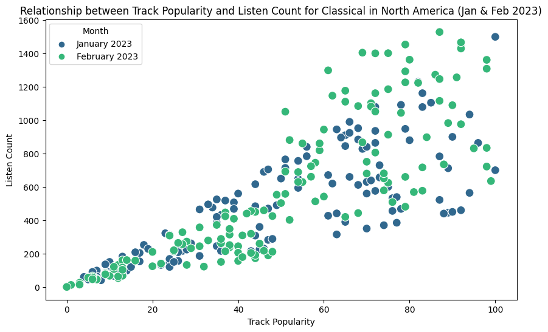

```python
import matplotlib.pyplot as plt
import seaborn as sns

# Filter data for the identified top genre
top_genre_data = na_data[na_data['genre'] == top_genre]

# Visualization
plt.figure(figsize=(10, 6))
sns.scatterplot(data=top_genre_data, x='track_popularity', y='listen_count', hue='listen_month', palette="viridis", s=100)
plt.title(f'Relationship between Track Popularity and Listen Count for {top_genre} in North America (Jan & Feb 2023)')
plt.xlabel('Track Popularity')
plt.ylabel('Listen Count')
plt.legend(title='Month')
plt.show()
```

The visualization displays the relationship between track popularity and listen count for the identified genre in North America.

### Step 4: Comments & Insights

**Comments**:

- Tracks with higher popularity in January have an even higher listen count in February, indicating growing momentum.
- There is a positive correlation between track popularity and listen count, which means more popular tracks are listened to more frequently.
- There could be outliers: tracks with high popularity but low listen count or vice versa. Such tracks can be further investigated for anomalies or unique characteristics.

**Insights**:

- Spotify could prioritize such trending genres in North America for advertisements, playlist recommendations, and collaborations.
- Artists in this genre could plan tours or promotions based on this rising popularity in North America.